# Research_Methods_RMD

Sydney_Bliss

2018-02-16

#### Breeding Phenology and Performance of Swallows in the Maritimes

**Background**  
Aerial insectivore populations, including Tree (Tachycineta bicolor) and Barn (Hirundo rustica) Swallows, have experiences precipitous population declines sine the 1970s in North America. There are indications that there may be a concurrent decline in insect populations, coupled with earlier spring emergence driven by climate change. Such a decline in insect population would likely alter the breeding phenology and performance of swallows, and may be linked to species-wide population declines. In the absence of insect abundance data, weather data - which influences insect abundance - can instead by used to examine relationship between food availability, and swallow breeding phenology and performance.

**Biological Questions**  
**Q1** - Has swallow breeding phenology (clutch inition data) changed from 1962-2016?  
Hypothesis - both spp. with have advanced CID over time  
Rationale - insects are likely emerging earlier due to advanced spring thaw-up, and swallows have adjusted their phenology in response

**Q2** - Has swallow breeding performace (chick survival) changed from 1962-2016?  
Hypothesis - chick survival has decreased over time, contributing tothe overall popualtion decline in both spp. Rationale - decreased chick survvial (one measure of breeding performance) would be an obvious explanation as to why populations have broadly declined. IF chick survival has not changed, it suggests declines may be occuring at other points of the annual cycle (ex. high mrtality during mgration or overwintering)  
NOTE - could also examine other measures of breeding performance such as clutchsize and brood size

**Q3** - Is breeding phenology affected by climate?  
Hypothesis - rainfall and temperature variables will explain the most variation in CID  
Rationale - rainfall and temperature are both positively associated with insect abundance, and likely emergence

**Q4** - Is breeding performance affected by climate?  
Hypothesis - chick survival has been negatively affected by changes in climate  
Rationale - if swallow breeding performance has declined over time, the most obvious explanation is a decrease in insect populations driven by climate change

**STEP 1: IMPORT PACKAGES & DATA**

```r
library(tidyverse)

rm(list = ls()) #clear environment
swallows.df <- read_csv("swallows.csv") # import dataset and save to an object
problems(swallows.df) #ensure tibble is of the correct dimensions
```

```
## # tibble [0 × 4]
## # ... with 4 variables: row <int>, col <int>, expected <chr>, actual <chr>
```

**STEP 2: TIDY THE DATA**

Drop unnecessary columns to simplify the data frame:

```r
swallows.df <- select(swallows.df, Species, NestID, Province, Clutch.Num, Site, Latitude, Longitude, Year, CID, HD, CS, BS, SD12, minFt, minJFt, medJFt, medJp, meanMAp)
```

Create 3 time bins: 1) 1960-1972, 2) 1973-2005, 3) 2006-2016 so changes during, in the initial years of, and in the later years of, swallow declines can be examined seperately:

```r
swallows.df <- swallows.df %>% mutate(Yr = cut(Year, breaks = c(1959, 1972, 2005, 2016), labels = c("1960-1972", "1973-2005", "2006-2016")))
summary(swallows.df)     # have 1 outlier
```

```
##    Species             NestID            Province           Clutch.Num
##  Length:6692        Length:6692        Length:6692        Min.   :1.000
##  Class :character   Class :character   Class :character   1st Qu.:1.000
##  Mode  :character   Mode  :character   Mode  :character   Median :1.000
##                                                           Mean   :1.168
##                                                           3rd Qu.:1.000
##                                                           Max.   :2.000
##                                                           NA's   :6448
##      Site              Latitude       Longitude           Year
##  Length:6692        Min.   :43.39   Min.   :-68.99   Min.   :1960
##  Class :character   1st Qu.:45.05   1st Qu.:-66.76   1st Qu.:1979
##  Mode  :character   Median :45.35   Median :-64.97   Median :1991
##                     Mean   :45.44   Mean   :-65.30   Mean   :1992
##                     3rd Qu.:45.93   3rd Qu.:-64.33   3rd Qu.:2004
##                     Max.   :48.06   Max.   :-59.82   Max.   :2016
##                     NA's   :1       NA's   :1
##       CID              HD               CS              BS
##  Min.   : 4.00   Min.   : 15.00   Min.   :1.000   Min.   :0.000
##  1st Qu.:22.00   1st Qu.: 43.00   1st Qu.:5.000   1st Qu.:4.000
##  Median :28.00   Median : 47.00   Median :5.000   Median :5.000
##  Mean   :30.43   Mean   : 48.96   Mean   :5.154   Mean   :4.151
##  3rd Qu.:35.00   3rd Qu.: 52.00   3rd Qu.:6.000   3rd Qu.:6.000
##  Max.   :96.00   Max.   :107.00   Max.   :8.000   Max.   :8.000
##  NA's   :3738    NA's   :4260     NA's   :1807    NA's   :1992
##       SD12           minFt            minJFt           medJFt
##  Min.   :0.000   Min.   :-39.00   Min.   :-41.70   Min.   :-17.000
##  1st Qu.:0.000   1st Qu.:-25.30   1st Qu.:-25.00   1st Qu.: -8.800
##  Median :4.000   Median :-21.40   Median :-21.60   Median : -5.800
##  Mean   :3.434   Mean   :-21.61   Mean   :-21.85   Mean   : -6.522
##  3rd Qu.:5.000   3rd Qu.:-17.70   3rd Qu.:-17.80   3rd Qu.: -4.300
##  Max.   :8.000   Max.   : -6.70   Max.   : -7.60   Max.   :  2.000
##  NA's   :3166    NA's   :86       NA's   :61       NA's   :86
##      medJp           meanMAp               Yr
##  Min.   :0.0000   Min.   : 0.460   1960-1972:1041
##  1st Qu.:0.0000   1st Qu.: 2.340   1973-2005:4123
##  Median :0.0000   Median : 2.930   2006-2016:1528
##  Mean   :0.5859   Mean   : 3.135
##  3rd Qu.:1.0000   3rd Qu.: 3.800
##  Max.   :7.1000   Max.   :10.090
##  NA's   :207      NA's   :124
```

Change SD12 variable (# of chicks that survived to day 12, count data) to the % of the clutch that survived, to get survival rate:

```r
swallows.df <- swallows.df %>% mutate(Surv.Rate = SD12 / CS)
summary(swallows.df)
```

```
##    Species             NestID            Province           Clutch.Num
##  Length:6692        Length:6692        Length:6692        Min.   :1.000
##  Class :character   Class :character   Class :character   1st Qu.:1.000
##  Mode  :character   Mode  :character   Mode  :character   Median :1.000
##                                                           Mean   :1.168
##                                                           3rd Qu.:1.000
##                                                           Max.   :2.000
##                                                           NA's   :6448
##      Site              Latitude       Longitude           Year
##  Length:6692        Min.   :43.39   Min.   :-68.99   Min.   :1960
##  Class :character   1st Qu.:45.05   1st Qu.:-66.76   1st Qu.:1979
##  Mode  :character   Median :45.35   Median :-64.97   Median :1991
##                     Mean   :45.44   Mean   :-65.30   Mean   :1992
##                     3rd Qu.:45.93   3rd Qu.:-64.33   3rd Qu.:2004
##                     Max.   :48.06   Max.   :-59.82   Max.   :2016
##                     NA's   :1       NA's   :1
##       CID              HD               CS              BS
##  Min.   : 4.00   Min.   : 15.00   Min.   :1.000   Min.   :0.000
##  1st Qu.:22.00   1st Qu.: 43.00   1st Qu.:5.000   1st Qu.:4.000
##  Median :28.00   Median : 47.00   Median :5.000   Median :5.000
##  Mean   :30.43   Mean   : 48.96   Mean   :5.154   Mean   :4.151
##  3rd Qu.:35.00   3rd Qu.: 52.00   3rd Qu.:6.000   3rd Qu.:6.000
##  Max.   :96.00   Max.   :107.00   Max.   :8.000   Max.   :8.000
##  NA's   :3738    NA's   :4260     NA's   :1807    NA's   :1992
##       SD12           minFt            minJFt           medJFt
##  Min.   :0.000   Min.   :-39.00   Min.   :-41.70   Min.   :-17.000
##  1st Qu.:0.000   1st Qu.:-25.30   1st Qu.:-25.00   1st Qu.: -8.800
##  Median :4.000   Median :-21.40   Median :-21.60   Median : -5.800
##  Mean   :3.434   Mean   :-21.61   Mean   :-21.85   Mean   : -6.522
##  3rd Qu.:5.000   3rd Qu.:-17.70   3rd Qu.:-17.80   3rd Qu.: -4.300
##  Max.   :8.000   Max.   : -6.70   Max.   : -7.60   Max.   :  2.000
##  NA's   :3166    NA's   :86       NA's   :61       NA's   :86
##      medJp           meanMAp               Yr         Surv.Rate
##  Min.   :0.0000   Min.   : 0.460   1960-1972:1041   Min.   :0.000
##  1st Qu.:0.0000   1st Qu.: 2.340   1973-2005:4123   1st Qu.:0.333
##  Median :0.0000   Median : 2.930   2006-2016:1528   Median :0.833
##  Mean   :0.5859   Mean   : 3.135                    Mean   :0.663
##  3rd Qu.:1.0000   3rd Qu.: 3.800                    3rd Qu.:1.000
##  Max.   :7.1000   Max.   :10.090                    Max.   :1.000
##  NA's   :207      NA's   :124                       NA's   :3459
```

Outlier in CID variable (value = 96, or Aug 4) which is biologically unlikely. Probably due to recording error. Drop outlier:

```r
swallows.df <- filter(swallows.df, CID < 95)
summary(swallows.df)
str(swallows.df)
```

[output not shown]

Make a tibble for each species so they can be examined seperately:

```r
TRES.df <- filter(swallows.df, Species == "TRES")  # tree swallows
BARS.df <- filter(swallows.df, Species == "BARS")  # barn swallows
```

**STEP 3: VISUALIZE DATA for each biological question**

Histogram to see how many records exist for each species - likely unbalanced due to volunteer effort:

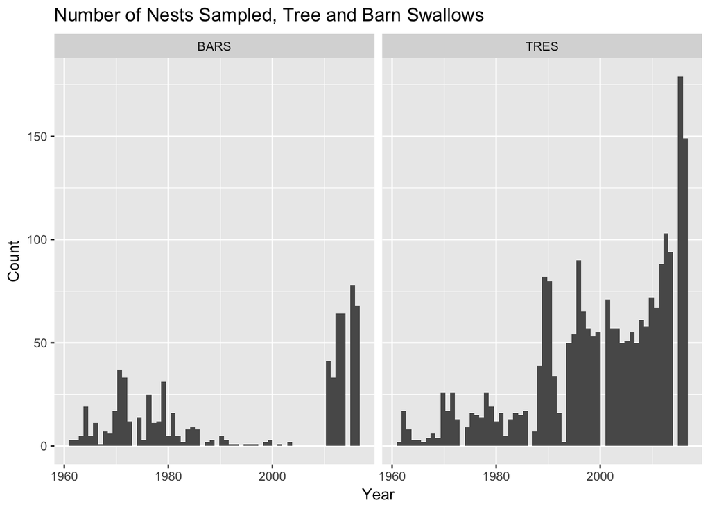

```r
ggplot(swallows.df, aes(x = Year)) +
  geom_histogram(bins = 60) +
  facet_grid(. ~ Species) +
  xlab("Year") +
  ylab("Count") +
  labs(title = "Number of Nests Sampled, Tree and Barn Swallows")
```

**Q1** - changes in breeding phenology  
Look at clutch initiation date (CID) in both species over time. Use scatterplot to see the spread of the data and boxplot to see how mean is changing:

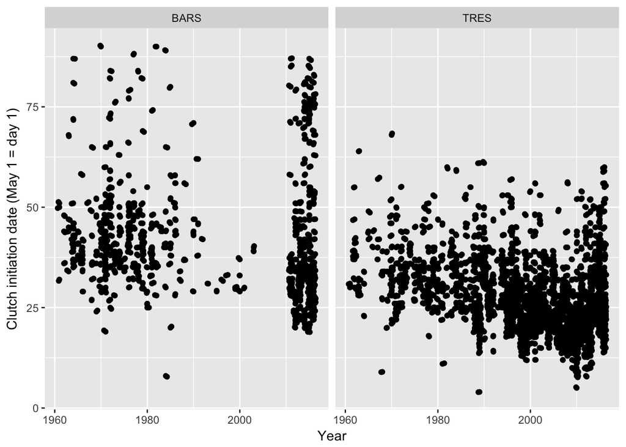

```r
ggplot(swallows.df, aes(Year, CID)) +
  geom_point() +
  geom_jitter() +
  xlab("Year") +
  ylab("Clutch initiation date (May 1 = day 1)") +
  facet_grid(. ~ Species)
```

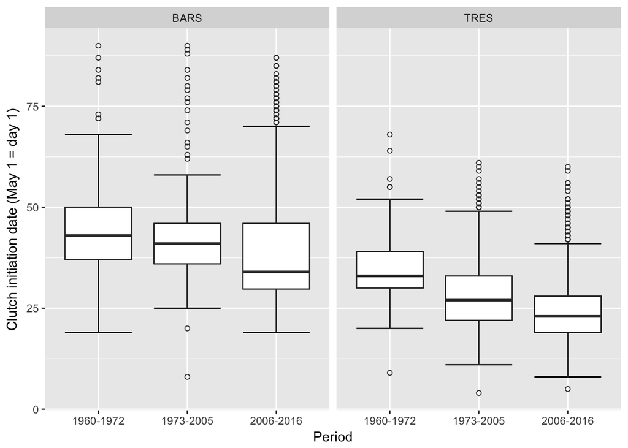

```r
ggplot(swallows.df, aes(Yr, CID)) +
  stat_boxplot(geom="errorbar") +
  geom_boxplot(outlier.shape=1) +
  xlab("Period") + ylab("Clutch initiation date (May 1 = day 1)") +
  facet_grid(. ~ Species)
```

Given that Barn Swallows are double-brooded and data are bimodal, it’s easier to examine clutch initiation date if data are visualized differently.

As nest-checks were largely opportunistic due to reliance on volunteer effort, it is unclear if for most records if it a first or second clutch, and unkown if nest-searching occured late enough in the season to detect second clutches. Therefore, only data from the three most recent years will be used. In these years, a monitoring prgram existed for the entire nesting period, and it is known if a clutch was the first or second for each record.

Tidy Barn Swallow data, then try a violin plot:

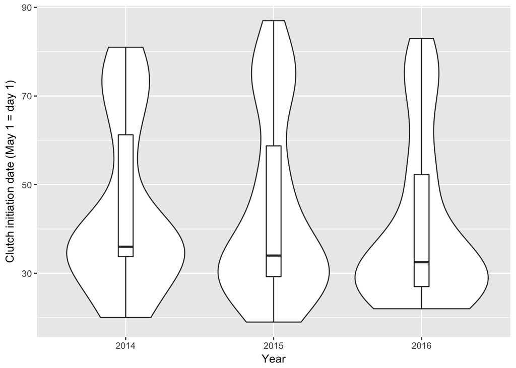

```r
BARS.df$Year <- as.factor(BARS.df$Year)

BARS.df$Clutch.Num <- as.factor(BARS.df$Clutch.Num)

BARS.df <- filter(BARS.df, Clutch.Num == "1" | Clutch.Num == "2")

ggplot(BARS.df, aes(Year, CID)) +
  geom_violin() +
  stat_summary(fun.y=median, geom="point", size=3) +
  geom_boxplot(width=0.1) +
  xlab("Year") +
  ylab("Clutch initiation date (May 1 = day 1)")
```

**Q2** - changes breeding performance Look at % of clutch that survived (Surv.Rate) in both species. Use boxplot and scatterplot as both are difficult to interpret by themselves:

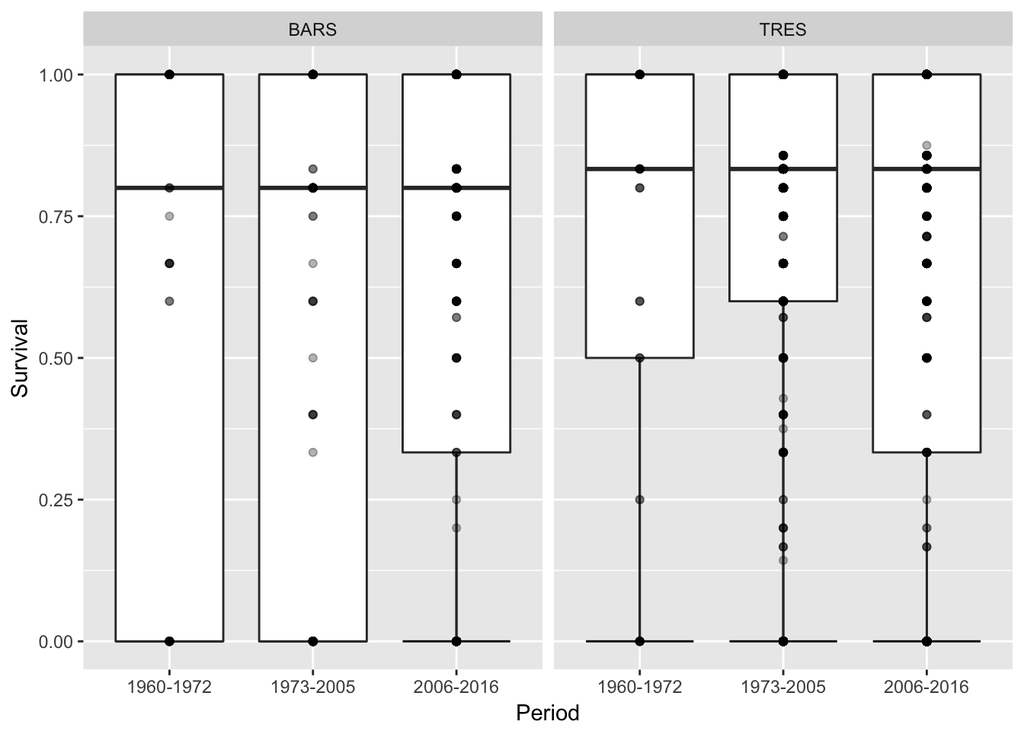

```r
ggplot(swallows.df, aes(Yr, Surv.Rate)) +
  stat_boxplot(geom="errorbar") +
  geom_boxplot(outlier.shape=1) +
  xlab("Period") + ylab("Survival") +
  facet_grid(. ~ Species)  +
  geom_point(alpha=0.3)
```

**Q3** - breeding phenology & climate Are there relationships between the climate variables and CID?

Climate Variable #1 - minimum February temperature (minFt). Looks like minFt has a negative relationship with CID

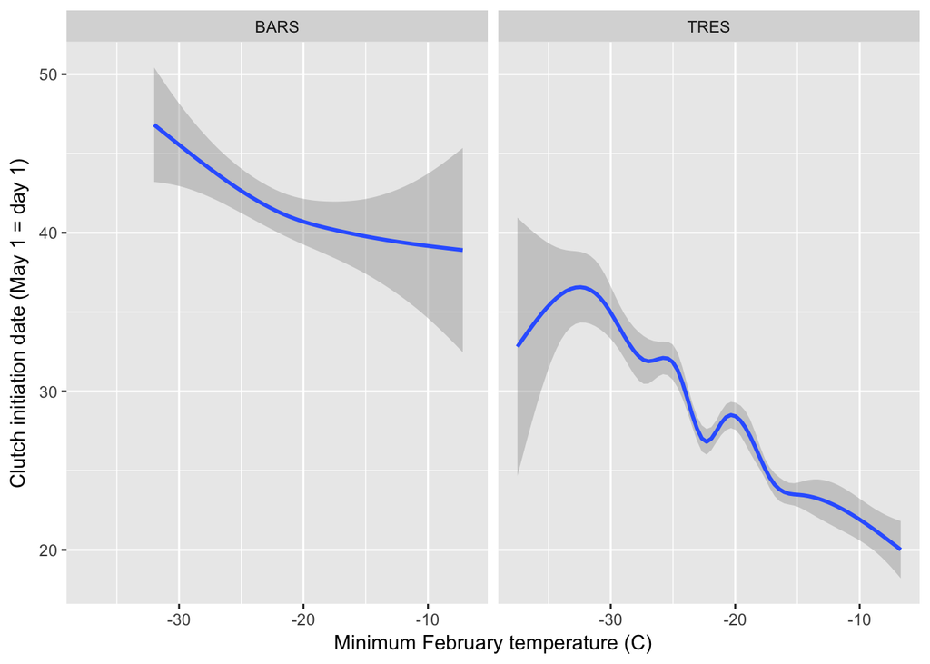

```r
ggplot(swallows.df, aes(minFt, CID)) +
    geom_smooth(mapping = aes(x = minFt, y = CID)) +
    xlab("Minimum February temperature (C)") +
    ylab("Clutch initiation date (May 1 = day 1)") +
    facet_grid(. ~ Species)
```

If seperate Barn Swallow clutches, now looks like no change over time:

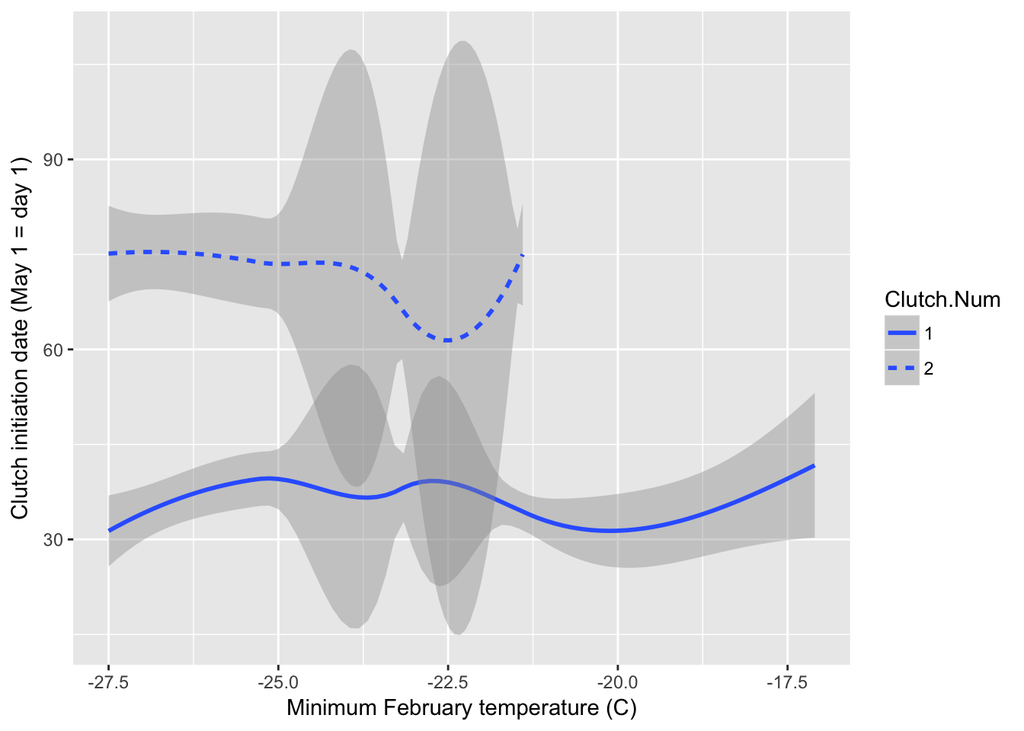

```r
ggplot(BARS.df, aes(minFt, CID)) +
  geom_smooth(mapping = aes(x = minFt, y = CID, linetype = Clutch.Num)) +
  xlab("Minimum February temperature (C)") +
  ylab("Clutch initiation date (May 1 = day 1)")
```

Climate Variable #2 - minimum January-February temperature (minJFt). Looks like minJFt has a negative relationship with CID in TRES, but not in BARS

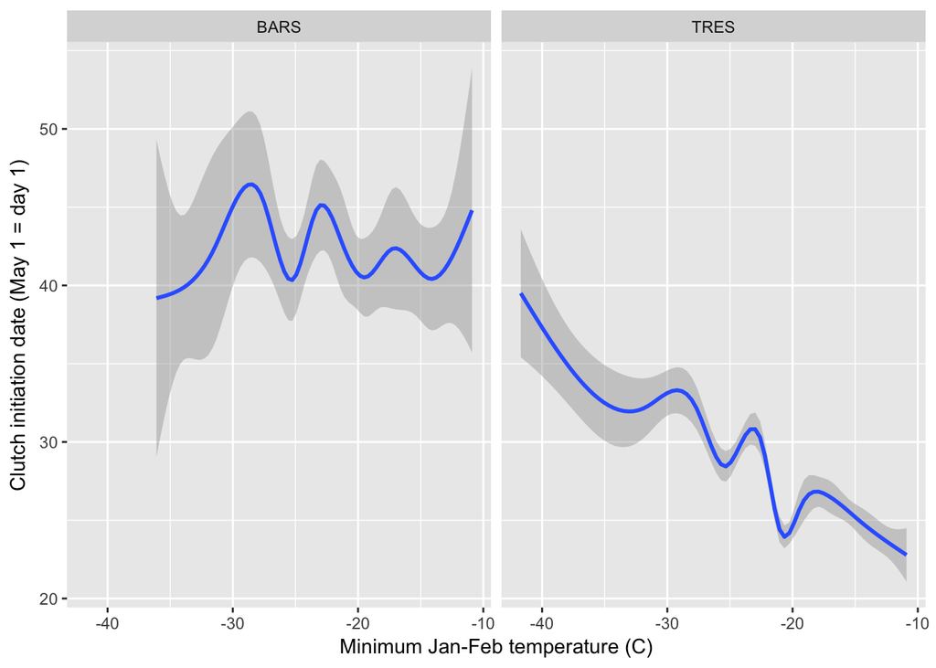

```r
ggplot(swallows.df, aes(minJFt, CID)) +
    geom_smooth(mapping = aes(x = minJFt, y = CID)) +
    xlab("Minimum Jan-Feb temperature (C)") +
    ylab("Clutch initiation date (May 1 = day 1)") +
    facet_grid(. ~ Species)
```

If seperate Barn Swallow clutches, looks like the first clutch could initiate later in warmer years (counterintuitive), but it’s not a strong relationship.

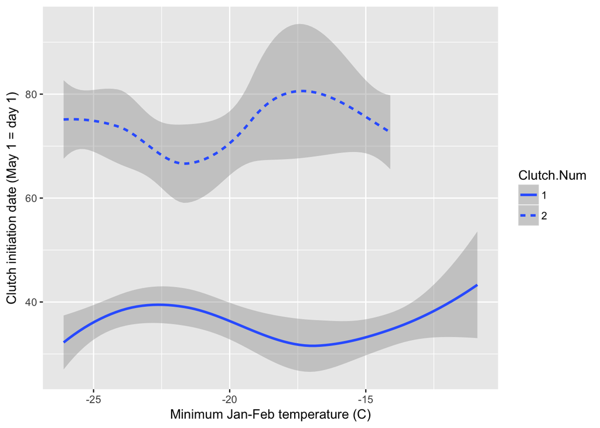

```r
ggplot(BARS.df, aes(minJFt, CID)) +
  geom_smooth(mapping = aes(x = minJFt, y = CID, linetype = Clutch.Num)) +
  xlab("Minimum Jan-Feb temperature (C)") +
  ylab("Clutch initiation date (May 1 = day 1)")
```

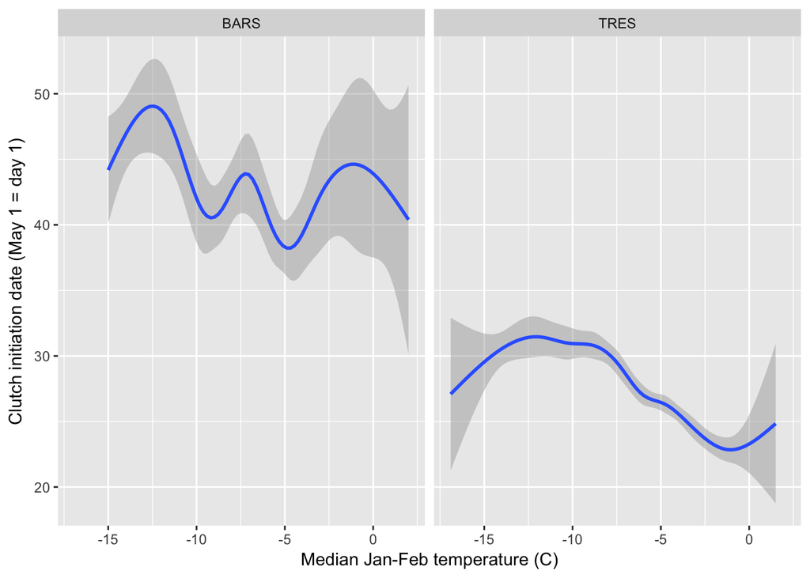

```r
ggplot(swallows.df, aes(medJFt, CID)) +
  geom_smooth(mapping = aes(x = medJFt, y = CID)) +
  xlab("Median Jan-Feb temperature (C)") +
  ylab("Clutch initiation date (May 1 = day 1)") +
  facet_grid(. ~ Species)
```

If seperate Barn Swallow clutches, still does not appear to be a consistent relationship.

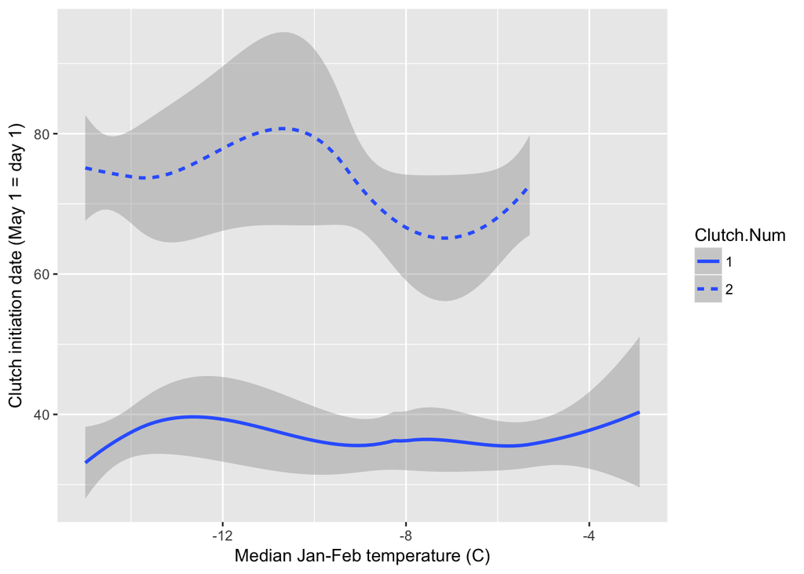

```r
ggplot(BARS.df, aes(medJFt, CID)) +
  geom_smooth(mapping = aes(x = medJFt, y = CID, linetype = Clutch.Num)) +
  xlab("Median Jan-Feb temperature (C)") +
  ylab("Clutch initiation date (May 1 = day 1)")
```

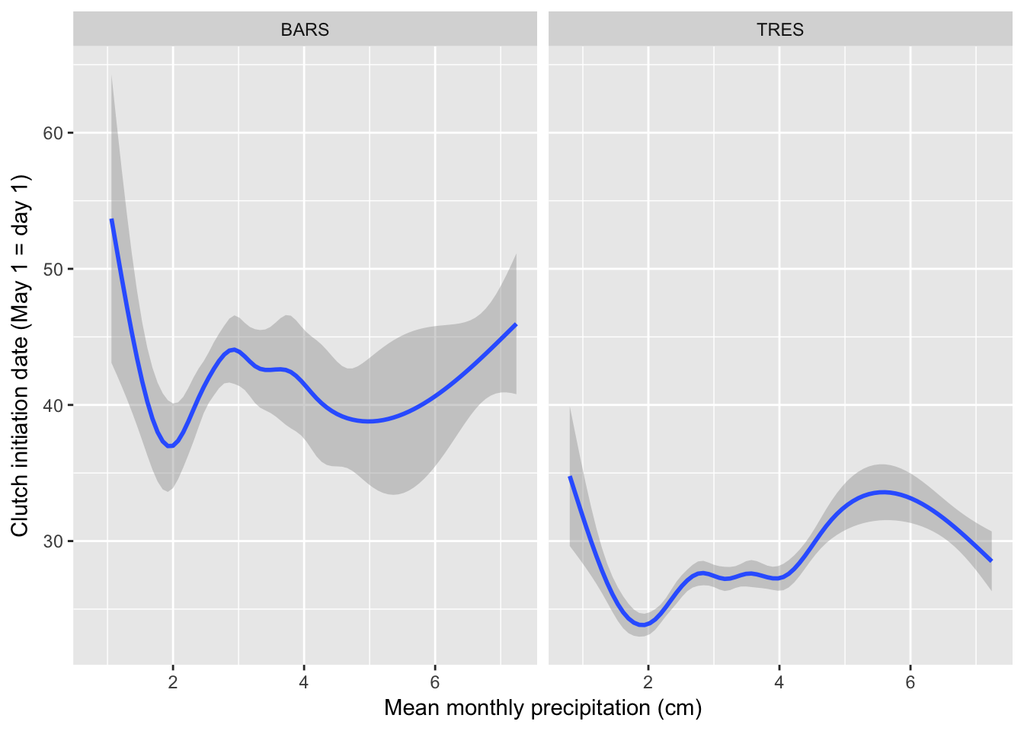

```r
ggplot(swallows.df, aes(meanMAp, CID)) +
  geom_smooth(mapping = aes(x = meanMAp, y = CID)) +
  xlab("Mean monthly precipitation (cm)") +
  ylab("Clutch initiation date (May 1 = day 1)") +
  facet_grid(. ~ Species)
```

If seperate Barn Swallow clutches, now looks like mean MAp has no relationship on clutch initiation on this spp.

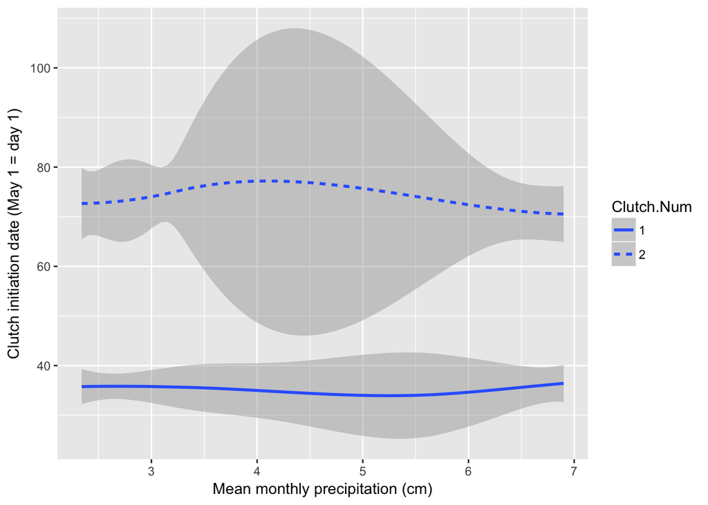

```r
ggplot(BARS.df, aes(meanMAp, CID)) +
  geom_smooth(mapping = aes(x = meanMAp, y = CID, linetype = Clutch.Num)) +
  xlab("Mean monthly precipitation (cm)") +
  ylab("Clutch initiation date (May 1 = day 1)")
```